# HW2_PCA_clustering

## Homework 2

Please submit both an .ipynb version and an .html version (for easier visualization on Canvas)

```python
# Make sure you are running on Colab
if 'google.colab' in str(get_ipython()):
    print('Running on CoLab')
    !pip install yellowbrick
    !pip install gower
    !pip install scikit-learn-extra
    !pip install kmodes
```

```python
import numpy as np # linear algebra
import pandas as pd # data processing, CSV file I/O (e.g. pd.read_csv)
import matplotlib.pyplot as plt # for data visualization
import seaborn as sns # for statistical data visualization
from sklearn.decomposition import PCA
from sklearn.preprocessing import MinMaxScaler,StandardScaler
import plotly.express as px
# %matplotlib inline
import warnings
warnings.filterwarnings('ignore') # Ignore warnings
```

## PCA and Clustering

Delta Airlines' website have data on all of their aircraft in a certain site section. In this homework, we will investigate the different aircraft in Delta’s fleet. Which planes are similar? Which are dissimilar?

```python
# We begin by loading inspecting the data
delta_data = pd.read_csv('delta.csv', index_col=0).reset_index()
```

```python
delta_data.head()
```

|  | Aircraft | Seat Width (Club) | Seat Pitch (Club) | Seat (Club) | Seat Width (First Class) | Seat Pitch (First Class) | Seats (First Class) | Seat Width (Business) | Seat Pitch (Business) | Seats (Business) | ... | Video | Power | Satellite | Flat-bed | Sleeper | Club | First Class | Business | Eco Comfort | Economy |
| --- | --- | --- | --- | --- | --- | --- | --- | --- | --- | --- | --- | --- | --- | --- | --- | --- | --- | --- | --- | --- | --- |
| 0 | Airbus A319 | 0.0 | 0 | 0 | 21.0 | 36.0 | 12 | 0.0 | 0.0 | 0 | ... | 0 | 0 | 0 | 0 | 0 | 0 | 1 | 0 | 1 | 1 |
| 1 | Airbus A319 VIP | 19.4 | 44 | 12 | 19.4 | 40.0 | 28 | 21.0 | 59.0 | 14 | ... | 1 | 0 | 0 | 0 | 0 | 1 | 1 | 1 | 0 | 0 |
| 2 | Airbus A320 | 0.0 | 0 | 0 | 21.0 | 36.0 | 12 | 0.0 | 0.0 | 0 | ... | 0 | 0 | 0 | 0 | 0 | 0 | 1 | 0 | 1 | 1 |
| 3 | Airbus A320 32-R | 0.0 | 0 | 0 | 21.0 | 36.0 | 12 | 0.0 | 0.0 | 0 | ... | 0 | 0 | 0 | 0 | 0 | 0 | 1 | 0 | 1 | 1 |
| 4 | Airbus A330-200 | 0.0 | 0 | 0 | 0.0 | 0.0 | 0 | 21.0 | 60.0 | 32 | ... | 1 | 1 | 0 | 1 | 0 | 0 | 0 | 1 | 1 | 1 |

5 rows × 34 columns

### Exercise 1: check correlation with visualization

**(1 point)** Visualize pairwise correlation using scatterplot for columns `'Accommodation', 'Cruising Speed (mph)', 'Range (miles)', 'Engines', 'Wingspan (ft)', 'Tail Height (ft)', 'Length (ft)'` (i.e., columns 16-23 in `delta_data`)

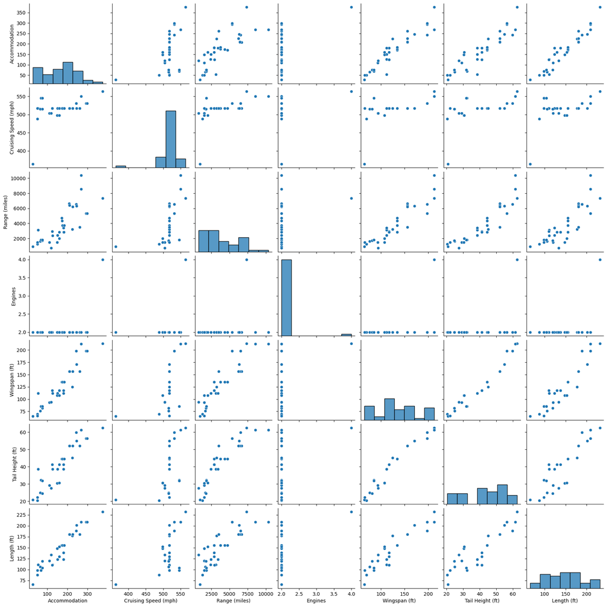

```python
comp_df = pd.DataFrame(delta_data,columns=['Accommodation', 'Cruising Speed (mph)', 'Range (miles)', 'Engines', 'Wingspan (ft)', 'Tail Height (ft)', 'Length (ft)'])
sns.pairplot(comp_df)
```

### Exercise 2: Prepare X

**(1 point)** Identify all binary columns (i.e., a binary column is the column that only contains `0` and `1` as values)

**(1 point)** Generate a dataframe `X` removing these binary columns and column `Aircraft` (since this is the `y`)

```python
binary_columns = []
for column in delta_data.columns:
    unique_values = delta_data[column].unique()
    if len(unique_values) == 2 and 0 in unique_values and 1 in unique_values:
        binary_columns.append(column)

print(binary_columns)
```

```
['Wifi', 'Video', 'Power', 'Satellite', 'Flat-bed', 'Sleeper', 'Club', 'First Class', 'Business', 'Eco Comfort', 'Economy']
```

```python
columns_to_remove = binary_columns + ["Aircraft"]

X = delta_data.drop(columns=columns_to_remove)
```

```python
X
```

|  | Seat Width (Club) | Seat Pitch (Club) | Seat (Club) | Seat Width (First Class) | Seat Pitch (First Class) | Seats (First Class) | Seat Width (Business) | Seat Pitch (Business) | Seats (Business) | Seat Width (Eco Comfort) | ... | Seat Width (Economy) | Seat Pitch (Economy) | Seats (Economy) | Accommodation | Cruising Speed (mph) | Range (miles) | Engines | Wingspan (ft) | Tail Height (ft) | Length (ft) |
| --- | --- | --- | --- | --- | --- | --- | --- | --- | --- | --- | --- | --- | --- | --- | --- | --- | --- | --- | --- | --- | --- |
| 0 | 0.0 | 0 | 0 | 21.0 | 36.0 | 12 | 0.0 | 0.00 | 0 | 17.20 | ... | 17.20 | 30.5 | 96 | 126 | 517 | 2399 | 2 | 111.830 | 38.5830 | 111.000 |
| 1 | 19.4 | 44 | 12 | 19.4 | 40.0 | 28 | 21.0 | 59.00 | 14 | 0.00 | ... | 0.00 | 0.0 | 0 | 54 | 517 | 3119 | 2 | 111.830 | 38.5830 | 111.000 |
| 2 | 0.0 | 0 | 0 | 21.0 | 36.0 | 12 | 0.0 | 0.00 | 0 | 17.20 | ... | 17.20 | 31.5 | 120 | 150 | 517 | 2420 | 2 | 111.830 | 38.5830 | 123.250 |
| 3 | 0.0 | 0 | 0 | 21.0 | 36.0 | 12 | 0.0 | 0.00 | 0 | 17.20 | ... | 17.20 | 31.5 | 120 | 150 | 517 | 2420 | 2 | 111.830 | 38.5830 | 123.250 |
| 4 | 0.0 | 0 | 0 | 0.0 | 0.0 | 0 | 21.0 | 60.00 | 32 | 18.00 | ... | 18.00 | 30.5 | 181 | 243 | 531 | 6536 | 2 | 197.830 | 59.8300 | 188.670 |
| 5 | 0.0 | 0 | 0 | 0.0 | 0.0 | 0 | 21.0 | 80.00 | 34 | 18.00 | ... | 18.00 | 30.5 | 168 | 243 | 531 | 6536 | 2 | 197.830 | 59.8300 | 188.670 |
| 6 | 0.0 | 0 | 0 | 0.0 | 0.0 | 0 | 21.0 | 80.00 | 34 | 18.00 | ... | 18.00 | 30.5 | 227 | 293 | 531 | 5343 | 2 | 197.830 | 56.3300 | 208.830 |
| 7 | 0.0 | 0 | 0 | 0.0 | 0.0 | 0 | 20.0 | 60.00 | 34 | 18.00 | ... | 18.00 | 30.5 | 232 | 298 | 531 | 5343 | 2 | 197.830 | 56.3300 | 208.830 |
| 8 | 0.0 | 0 | 0 | 19.6 | 37.0 | 12 | 0.0 | 0.00 | 0 | 18.10 | ... | 18.10 | 31.0 | 83 | 110 | 504 | 1510 | 2 | 93.330 | 29.0830 | 120.000 |
| 9 | 0.0 | 0 | 0 | 21.0 | 37.0 | 12 | 0.0 | 0.00 | 0 | 17.20 | ... | 17.20 | 30.5 | 94 | 124 | 517 | 2925 | 2 | 117.416 | 41.1670 | 110.330 |
| 10 | 0.0 | 0 | 0 | 21.0 | 37.0 | 16 | 0.0 | 0.00 | 0 | 17.20 | ... | 17.20 | 30.5 | 126 | 124 | 517 | 2925 | 2 | 117.416 | 41.1670 | 110.330 |
| 11 | 0.0 | 0 | 0 | 21.0 | 38.0 | 16 | 0.0 | 0.00 | 0 | 17.20 | ... | 17.20 | 30.5 | 126 | 160 | 517 | 2850 | 2 | 117.416 | 41.1670 | 129.500 |
| 12 | 0.0 | 0 | 0 | 21.0 | 37.0 | 20 | 0.0 | 0.00 | 0 | 17.20 | ... | 17.20 | 30.5 | 139 | 180 | 517 | 2870 | 2 | 117.416 | 41.1670 | 138.167 |
| 13 | 0.0 | 0 | 0 | 0.0 | 0.0 | 0 | 20.5 | 82.00 | 48 | 17.20 | ... | 17.20 | 30.5 | 286 | 376 | 564 | 7365 | 4 | 213.000 | 62.5416 | 231.830 |
| 14 | 0.0 | 0 | 0 | 21.0 | 40.0 | 24 | 0.0 | 0.00 | 0 | 17.20 | ... | 17.20 | 31.0 | 132 | 174 | 517 | 4344 | 2 | 134.750 | 44.5000 | 155.250 |
| 15 | 0.0 | 0 | 0 | 0.0 | 0.0 | 0 | 21.0 | 54.50 | 16 | 17.20 | ... | 17.20 | 30.5 | 130 | 171 | 517 | 4705 | 2 | 134.750 | 44.5000 | 155.250 |
| 16 | 0.0 | 0 | 0 | 21.0 | 37.0 | 22 | 0.0 | 0.00 | 0 | 17.20 | ... | 17.20 | 31.0 | 141 | 181 | 517 | 2854 | 2 | 134.750 | 44.5000 | 155.250 |
| 17 | 0.0 | 0 | 0 | 21.0 | 37.0 | 22 | 0.0 | 0.00 | 0 | 17.20 | ... | 17.20 | 31.5 | 141 | 182 | 517 | 2854 | 2 | 134.750 | 44.5000 | 155.250 |
| 18 | 0.0 | 0 | 0 | 21.0 | 37.5 | 24 | 0.0 | 0.00 | 0 | 17.20 | ... | 17.20 | 31.5 | 136 | 180 | 517 | 3393 | 2 | 111.830 | 38.5830 | 123.250 |
| 19 | 0.0 | 0 | 0 | 21.0 | 45.0 | 22 | 0.0 | 0.00 | 0 | 17.20 | ... | 17.20 | 32.0 | 132 | 175 | 517 | 3764 | 2 | 134.750 | 44.5000 | 155.250 |
| 20 | 0.0 | 0 | 0 | 0.0 | 0.0 | 0 | 21.0 | 38.00 | 26 | 17.20 | ... | 17.20 | 31.5 | 132 | 184 | 517 | 3764 | 2 | 134.750 | 44.5000 | 155.250 |
| 21 | 0.0 | 0 | 0 | 21.0 | 37.0 | 24 | 0.0 | 0.00 | 0 | 17.20 | ... | 17.20 | 31.0 | 177 | 224 | 517 | 3228 | 2 | 124.830 | 45.0830 | 177.416 |
| 22 | 0.0 | 0 | 0 | 0.0 | 0.0 | 0 | 18.5 | 60.00 | 30 | 17.90 | ... | 17.90 | 31.5 | 140 | 208 | 517 | 6408 | 2 | 156.083 | 52.0000 | 180.250 |
| 23 | 0.0 | 0 | 0 | 0.0 | 0.0 | 0 | 21.0 | 78.95 | 36 | 17.90 | ... | 17.90 | 31.5 | 143 | 211 | 517 | 6408 | 2 | 156.083 | 52.0000 | 180.250 |
| 24 | 0.0 | 0 | 0 | 18.5 | 37.5 | 30 | 0.0 | 0.00 | 0 | 17.90 | ... | 17.90 | 31.5 | 203 | 261 | 517 | 3515 | 2 | 156.083 | 52.0000 | 180.250 |
| 25 | 0.0 | 0 | 0 | 18.5 | 37.5 | 30 | 0.0 | 0.00 | 0 | 17.90 | ... | 17.90 | 31.5 | 203 | 261 | 517 | 3515 | 2 | 156.083 | 52.0000 | 180.250 |
| 26 | 0.0 | 0 | 0 | 0.0 | 0.0 | 0 | 21.0 | 78.95 | 36 | 17.90 | ... | 17.90 | 31.5 | 143 | 208 | 517 | 6640 | 2 | 156.083 | 52.0000 | 180.250 |
| 27 | 0.0 | 0 | 0 | 18.5 | 60.0 | 36 | 0.0 | 0.00 | 0 | 17.90 | ... | 17.90 | 31.5 | 143 | 210 | 517 | 6408 | 2 | 156.083 | 52.0000 | 180.250 |
| 28 | 0.0 | 0 | 0 | 0.0 | 0.0 | 0 | 21.0 | 78.95 | 26 | 17.90 | ... | 17.90 | 31.5 | 171 | 226 | 517 | 6221 | 2 | 156.083 | 52.0000 | 180.250 |
| 29 | 0.0 | 0 | 0 | 0.0 | 0.0 | 0 | 21.0 | 78.95 | 26 | 17.90 | ... | 17.90 | 31.5 | 171 | 226 | 517 | 6221 | 2 | 156.083 | 52.0000 | 180.250 |
| 30 | 0.0 | 0 | 0 | 0.0 | 0.0 | 0 | 21.0 | 78.95 | 40 | 17.90 | ... | 17.90 | 31.5 | 178 | 246 | 517 | 6336 | 2 | 171.000 | 54.9170 | 201.330 |
| 31 | 0.0 | 0 | 0 | 0.0 | 0.0 | 0 | 21.0 | 78.00 | 45 | 18.50 | ... | 18.50 | 31.5 | 188 | 269 | 550 | 8542 | 2 | 212.583 | 61.3300 | 209.083 |
| 32 | 0.0 | 0 | 0 | 0.0 | 0.0 | 0 | 21.0 | 78.00 | 45 | 18.50 | ... | 18.50 | 31.5 | 188 | 269 | 550 | 10375 | 2 | 212.583 | 61.3300 | 209.083 |
| 33 | 0.0 | 0 | 0 | 0.0 | 0.0 | 0 | 0.0 | 0.00 | 0 | 0.00 | ... | 17.30 | 31.0 | 50 | 50 | 488 | 1265 | 2 | 69.583 | 20.4160 | 87.830 |
| 34 | 0.0 | 0 | 0 | 0.0 | 0.0 | 0 | 0.0 | 0.00 | 0 | 0.00 | ... | 17.30 | 31.0 | 50 | 50 | 488 | 1265 | 2 | 69.583 | 20.4160 | 87.830 |
| 35 | 0.0 | 0 | 0 | 19.6 | 36.0 | 9 | 0.0 | 0.00 | 0 | 17.30 | ... | 17.30 | 31.0 | 48 | 65 | 515 | 1650 | 2 | 76.250 | 24.8300 | 106.083 |
| 36 | 0.0 | 0 | 0 | 19.6 | 37.0 | 12 | 0.0 | 0.00 | 0 | 17.30 | ... | 17.30 | 31.0 | 52 | 76 | 515 | 1744 | 2 | 81.583 | 24.5830 | 118.916 |
| 37 | 0.0 | 0 | 0 | 0.0 | 0.0 | 0 | 0.0 | 0.00 | 0 | 0.00 | ... | 18.20 | 31.0 | 28 | 28 | 364 | 920 | 2 | 64.916 | 20.8300 | 65.583 |
| 38 | 0.0 | 0 | 0 | 20.0 | 37.0 | 9 | 0.0 | 0.00 | 0 | 18.25 | ... | 18.25 | 31.0 | 48 | 69 | 545 | 1800 | 2 | 85.416 | 32.3300 | 98.083 |
| 39 | 0.0 | 0 | 0 | 20.0 | 37.0 | 12 | 0.0 | 0.00 | 0 | 18.25 | ... | 18.25 | 31.0 | 52 | 76 | 545 | 1800 | 2 | 85.416 | 31.9160 | 103.916 |
| 40 | 0.0 | 0 | 0 | 0.0 | 0.0 | 0 | 0.0 | 0.00 | 0 | 0.00 | ... | 17.30 | 31.0 | 50 | 50 | 517 | 1496 | 2 | 65.750 | 22.1670 | 98.000 |
| 41 | 0.0 | 0 | 0 | 19.6 | 37.0 | 16 | 0.0 | 0.00 | 0 | 18.10 | ... | 18.10 | 32.0 | 118 | 149 | 498 | 1510 | 2 | 107.830 | 30.5000 | 147.830 |
| 42 | 0.0 | 0 | 0 | 19.6 | 37.0 | 16 | 0.0 | 0.00 | 0 | 18.10 | ... | 18.10 | 31.5 | 129 | 160 | 498 | 1992 | 2 | 107.830 | 30.5830 | 152.583 |
| 43 | 0.0 | 0 | 0 | 19.6 | 38.0 | 16 | 0.0 | 0.00 | 0 | 18.10 | ... | 18.10 | 31.0 | 90 | 120 | 504 | 731 | 2 | 93.830 | 27.5000 | 133.500 |

44 rows × 22 columns